# Visualiztion of a small sample of Eye-Tracking Data

The following is a demonstration of some basic visualization of eye tracking data. Using Engbert & Kliegl Microsaccade Detection Algorithm (2003), binocular positional data was plotted. Eye tracking data was collected with Eyelink 1000 Plus (SR Research) and data was collected while subjects observed a simple shape array; such display was designed using Python/Psychopy(https://www.youtube.com/watch?v=WCbu43Lbbuo).

Written by Darwin Romulus, PhD candidate at the Center for Complex Systems and Brain Sciences, Florida Atlantic University.

Dromulus2016@fau.edu

(917)293-6546

#### Clear all the variables in the global environment and set directory to where data is located. Read in some data with read.table function:

```r
rm(list=ls())
setwd("/Users/darwinromulus/Desktop/dummydata2") # folder where data is located
```

```
The working directory was changed to /Users/darwinromulus/Desktop/dummydata2 inside a notebook chunk. The working directory will be reset when the chunk is finished running. Use the knitr root.dir option in the setup chunk to change the working directory for notebook chunks.
```

```r
data = read.table("01_ray.dat") # read in
tr1_ray <- as.matrix(data)
```

#### 1000 hz is the sampling rate for Eye Tracker (Eyelink 1000 Plus, SR Research), 1000 samples are collected per second. Stimulus was presented for about 10 seconds, so each trial has about 10000 samples. This trial has 10004 samples.

```r
# 1000 hz is the sampling rate for Eye Tracker so 1000 samples where collected per second.
# Stimilus was presented for about 10 seconds, so each trial has about 10000 samples.
size = dim(tr1_ray) # number of samples in trial 1 (10004)
time_ms = 1:size[1]
tr1_ray[1:size[1],1] = time_ms
```

#### Normalize the gaze postional data with PPD (in respect to the center of screen). PPD is pixels per visual degree angle. Visual angle degree is based off screen size and the distance between the screen and the participant. Positional data will now have values between -1 and 1+.

```r
# 1001th time stamp is where shape presentation switches
# the amplitude of a saccade is the angular distance traveled by the eyes
ppd = 60 # 60 pixels per visual degree (based off of screensize and participant distance)
# screen is 32 deg (x) by 18 deg (y)
# divide all gaze positions in time series by ppd, gives you gaze pos in visual degrees
# then normalize the vis. degree by substracting and dividing by 16 (for x dim left/right)
# do the same for y dim for left/right eye (by substracting and dividing by 9)
# to find normalized gaze pos in respect to the center (and to get values btwn -1 and 1+)
# you have to substract/divide by center visual degree
tr1_ray[1:size[1],2]= ((tr1_ray[1:size[1],2]/ppd)-16)/16 # normalizing x dim for left eye
tr1_ray[1:size[1],4]= ((tr1_ray[1:size[1],4]/ppd)-16)/16 # normalizing x dim for right eye
tr1_ray[1:size[1],3]= ((tr1_ray[1:size[1],3]/ppd)-9)/9 # normalizing y dim for left eye
tr1_ray[1:size[1],5]= ((tr1_ray[1:size[1],5]/ppd)-9)/9 # normalizing y dim for right eye
tr1_ray = round(tr1_ray, digits=5)
```

#### Change directory to where Microsaccade functions are present (written by Engbert & Kliegl, 2003) and plot smoothed positional data for left and right eye:

```r
setwd("/Users/darwinromulus/Desktop/MS_Toolbox_R/MS_Toolbox_R")
source("vecvel.R")
source("microsacc.R")
source("binsacc.R")
source("smoothdata.R")
source("surrogate.R")
source("lagdist.R")
source("boxcount.R")
source("sacpar.R")
source("microFreq.R")
par(ask = TRUE)
SAMPLING = 1000
MINDUR = 6
VFAC = 5
xl = tr1_ray[1:size[1],2:3] # x and y pos for left eye
xr = tr1_ray[1:size[1],4:5] # x and y pos for right eye
# Apply running average
xls <- smoothdata(xl)
xrs <- smoothdata(xr)
```

#### Plots of smoothed postiontal data (x,y) for left and right eye. Notice how majority of the data lies close to the center; this is because participants were instructed to fixate on the center of the screen.

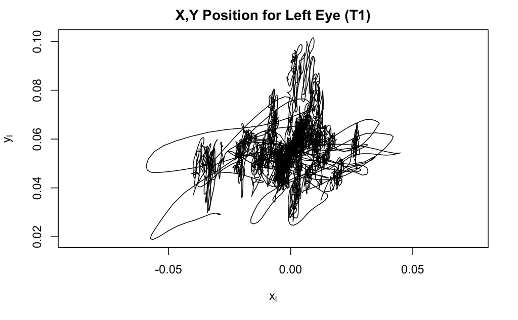

```r
plot(xls[,1],xls[,2],type='l',asp=1,
     xlab=expression(x[l]),ylab=expression(y[l]),
     main="X,Y Position for Left Eye (T1)")
```

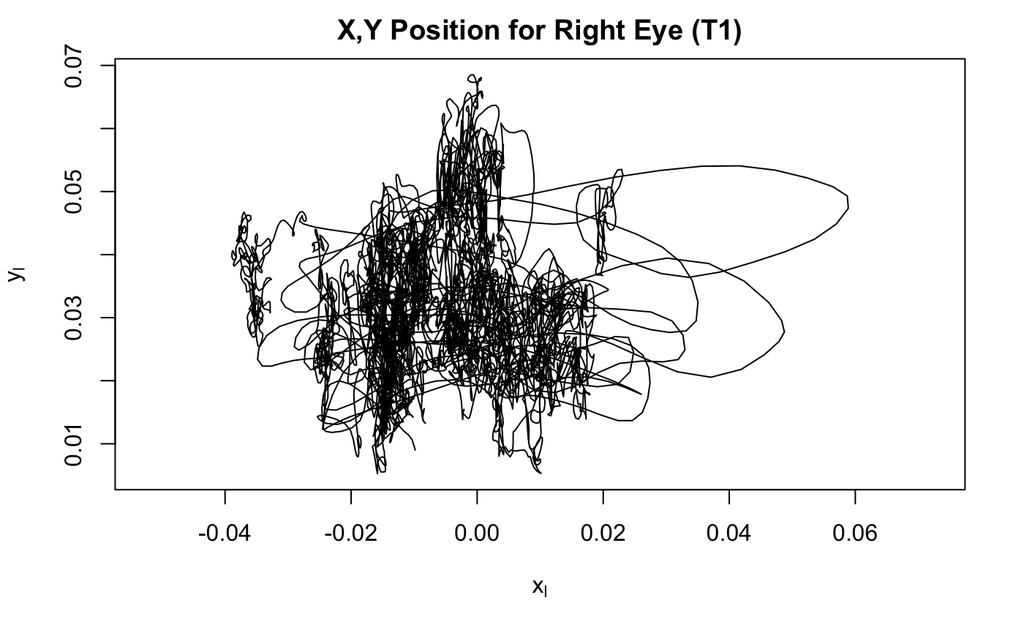

```r
plot(xrs[,1],xrs[,2],type='l',asp=1,
     xlab=expression(x[l]),ylab=expression(y[l]),
     main="X,Y Position for Right Eye (T1)")
```

#### Detection of microsaccades using microsaccade detection algorithm.

```r
# Detection of microsaccades
## trial 1
msl <- microsacc(xl,VFAC,MINDUR,SAMPLING) # detects potential monocular microsaccades, detection for left eye
msr <- microsacc(xr,VFAC,MINDUR,SAMPLING) # detection for right eye
sac <- binsacc(msl$table,msr$table) # detection of binocular microsaccades, for microsaccades that are occuring close in time
tab <- sacpar(sac)
N <- sac$N[1]
bin <- sac$bin
print(N)
```

```
[1] 29
```

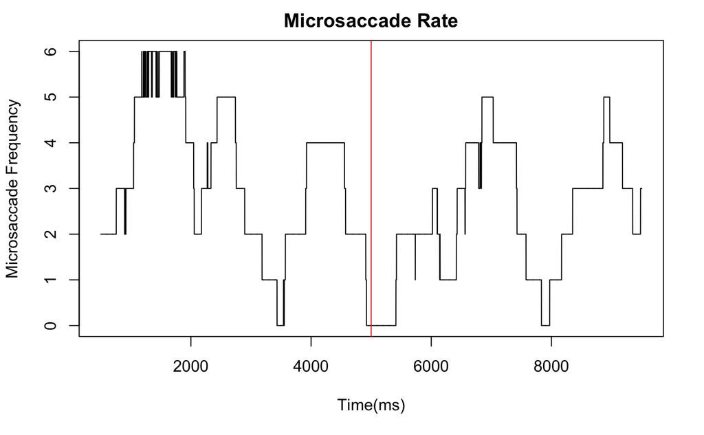

```r
x1 = microFreq(tr1_ray)
x1x = c(1:dim(x1)[1])
start = 1
end = 9004
sx1 = x1[start:end,]
xtime = vector()
for (i in 1:dim(sx1)[1]){
  t = (sx1[i,2] + sx1[i,3])/2
  xtime = c(xtime,t)
}
yfreq = sx1[,1]
xtime = c(xtime[1]:xtime[length(xtime)])
plot(xtime,yfreq, type='l', ylab="Microsaccade Frequency",xlab="Time(ms)", main = "Microsaccade Rate")
abline(v=5000,col="red")
```

#### Let’s observe a window that is closer around the time point where the shape display changes.

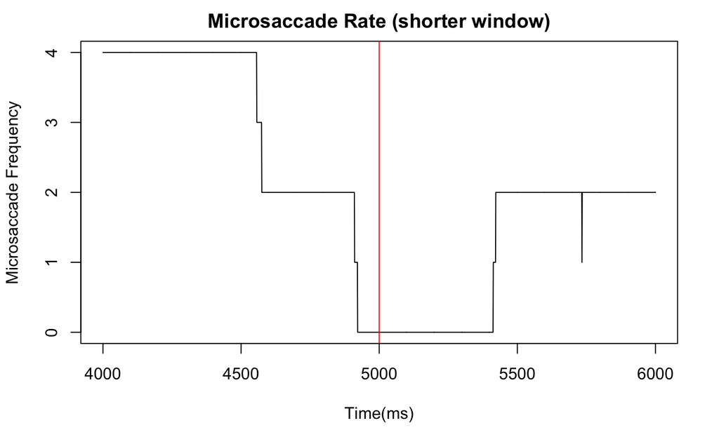

```r
start = 3500
end = 5500
sx1 = x1[start:end,]
xtime = vector()
for (i in 1:dim(sx1)[1]){
  t = (sx1[i,2] + sx1[i,3])/2
  xtime = c(xtime,t)
}
yfreq = sx1[,1]
xtime = c(xtime[1]:xtime[length(xtime)])
plot(xtime,yfreq, type='l', ylab="Microsaccade Frequency",xlab="Time(ms)", main = "Microsaccade Rate (shorter window)")
abline(v=5000,col="red")
```